# Reproducible Data Analysis using R

Part 4: spatial data visualization and flexdashboard

# Introduction to geospatial data

Geospatial data can broadly be divided into the following categories -

- Vectors - points, lines and polygons
- Rasters - data made up of pixels or cells (grids)

Further, these types of files can represent various themes including -

- Administrative boundaries
- Socio-Economic data
- Transportation networks
- Physical geography
- Data collected from other sensors (NDVI)

Today we will attempt to map some socio-economic factors onto vectors

# How to use maps?

Mapping data is stored in it’s own special files, or can be inferred from human readable data.

Ideally we would use already existing, cross-checked point-locations/shapefiles but in the absence of these, today we will attempt to create our own point locations for the UAs.

For the India and District boundaries, we shall use open source boundaries. (available here)

To do this, we will be using a free Google sheets plugin called “Awesome Table” (tutorial here; not recommended for official use - PLEASE USE EXISTING OFFICIAL BOUNDARIES AVAILABLE TO YOU)

# Flexdashboard

Flexdashboard is another package that allows us to create and customize Rmarkdown files to a much greater extent. We can add different layouts, interactivity as well as some dynamic controls.

# sf

sf is a package that allows us to handle files that have spatial data encoded in them. We are able to read & write, and perform operations on such files.

# Spatial data in R

#### Reading point location data and quick sanity check

How can we parse this Latitude and Longitude data into R? We rely on the “sf” package for this. After that we can create a quick simple graph to see whether the points make sense or not. For this, we shall use “ggplot2” again and simply add the “geom_sf” function to it.

```r
ua_points <- read_csv("data/spatial_data/ua_geocode.csv") #Reading it as csv directly
```

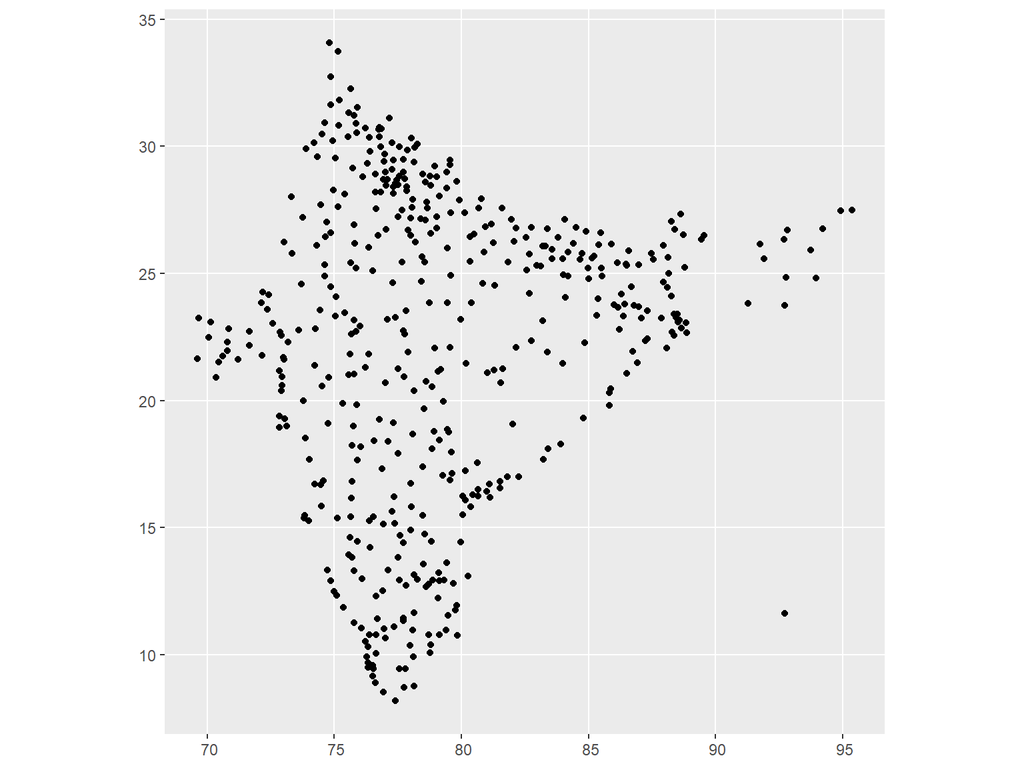

```r
ua_points <- st_as_sf(ua_points, coords = c("Longitude","Latitude")) #parsing to lat long info
plot <- ggplot(ua_points) +
  geom_sf()
plot
```

As we can see, this roughly forms the shape of India. We can be reasonably sure that most of our points are correct. For further maps, we shall also add a boundary of India for helping visibility.

# Adding data to maps

#### Merging with UA data

Now we shall try to merge this UA point location data with the data in the UA populations file we have created in the past.

```r
data <- read_csv("data/ua_populations.csv")
geo_data <- inner_join(ua_points, data, by = "ua_no")
geo_data
```

```
## Simple feature collection with 2777 features and 12 fields
## geometry type:  POINT
## dimension:      XY
## bbox:           xmin: 69.62931 ymin: 8.183286 xmax: 95.35576 ymax: 34.08367
## CRS:            NA
## # A tibble: 2,777 x 13
##    ua_no ua.x  country `Full Address`                  geometry ua.y   year
##    <dbl> <chr> <chr>   <chr>                            <POINT> <chr> <dbl>
##  1     1 Grea~ , India Greater Mumba~        (72.8345 18.94036) Grea~  1961
##  2     1 Grea~ , India Greater Mumba~        (72.8345 18.94036) Grea~  1971
##  3     1 Grea~ , India Greater Mumba~        (72.8345 18.94036) Grea~  1981
##  4     1 Grea~ , India Greater Mumba~        (72.8345 18.94036) Grea~  1991
##  5     1 Grea~ , India Greater Mumba~        (72.8345 18.94036) Grea~  2001
##  6     1 Grea~ , India Greater Mumba~        (72.8345 18.94036) Grea~  2011
##  7     2 Delhi , India Delhi   , Ind~       (77.10249 28.70406) Delh~  1961
##  8     2 Delhi , India Delhi   , Ind~       (77.10249 28.70406) Delh~  1971
##  9     2 Delhi , India Delhi   , Ind~       (77.10249 28.70406) Delh~  1981
## 10     2 Delhi , India Delhi   , Ind~       (77.10249 28.70406) Delh~  1991
## # ... with 2,767 more rows, and 6 more variables: area <dbl>, population <dbl>,
## #   pop_change <dbl>, pop_change_percent <dbl>, pop_male <dbl>,
## #   pop_female <dbl>
```

Why not names? Does order matter?

# Adding boundaries of India to the cities

Now, we shall plot this on a map with the boundary of India

```r
india <- st_read("data/spatial_data/india-soi.geojson")
```

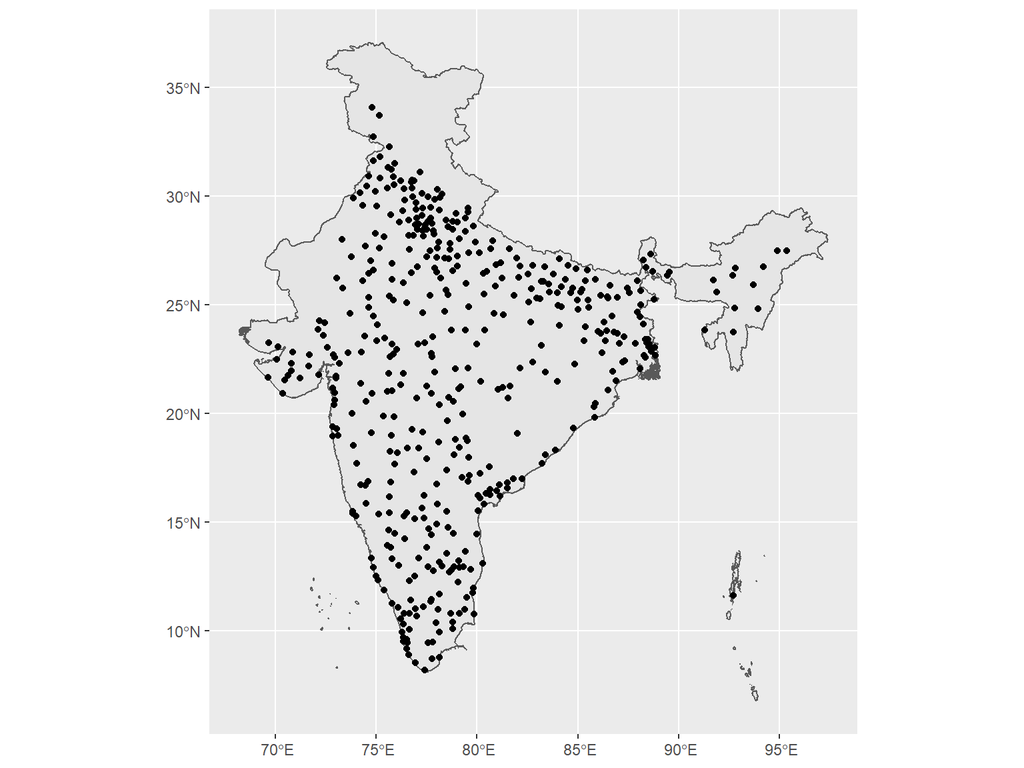

```r
st_crs(geo_data) <- st_crs("EPSG:4326")
plot <- ggplot() +
  geom_sf(data = india) +
  geom_sf(data = geo_data)
plot
```

# Plotting population on the map

We will plot the population as size of the point. Again to do this we just use “ggplot2” and add “aes()” to the “geom_sf” call

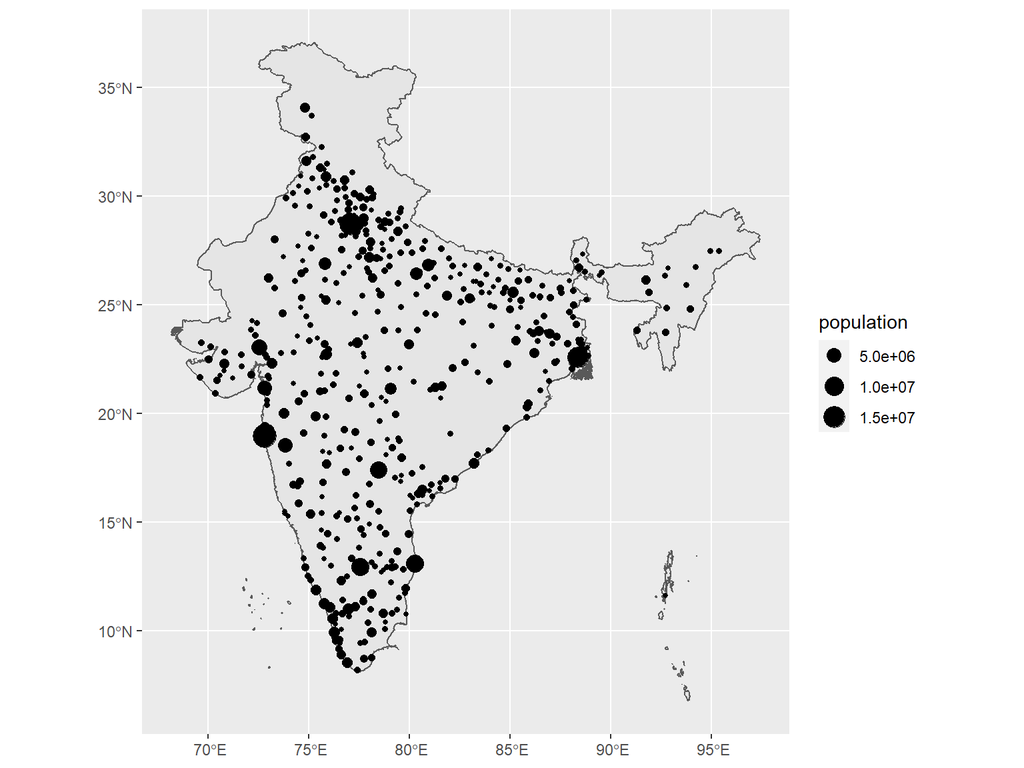

```r
library(dplyr) ## Why?
geo_data_2011 <- geo_data %>%
  filter(year == "2011")
plot <- ggplot() +
  geom_sf(data = india) +
  geom_sf(data = geo_data_2011, aes(size = population))
plot
```

We can see a familiar looking map in front of us. The big cities stand out and overall it makes more sense.

# Adding Sex ratio to this map

Now let’s try adding the sex ratio as a color to the same map

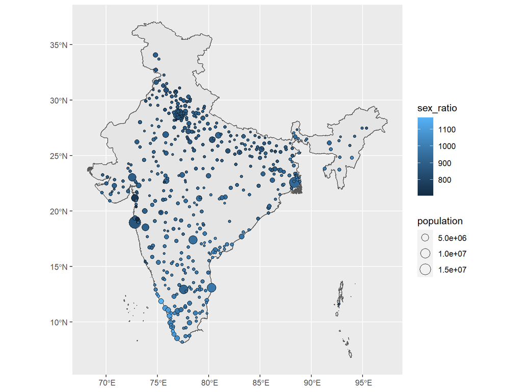

```r
geo_data_2011_sex_ratio <- geo_data %>%
  filter(year == "2011") %>%
  mutate(sex_ratio = 1000*pop_female/pop_male)

plot <- ggplot() +
  geom_sf(data = india) +
  geom_sf(data = geo_data_2011_sex_ratio, aes(size = population, fill = sex_ratio), shape = 21)
plot
```

# Improvements

#### Cleaning up and removing excess elements

While we do have all this information on the map, none of it is very clearly visible, so we shall try to make it more coherent and visible.

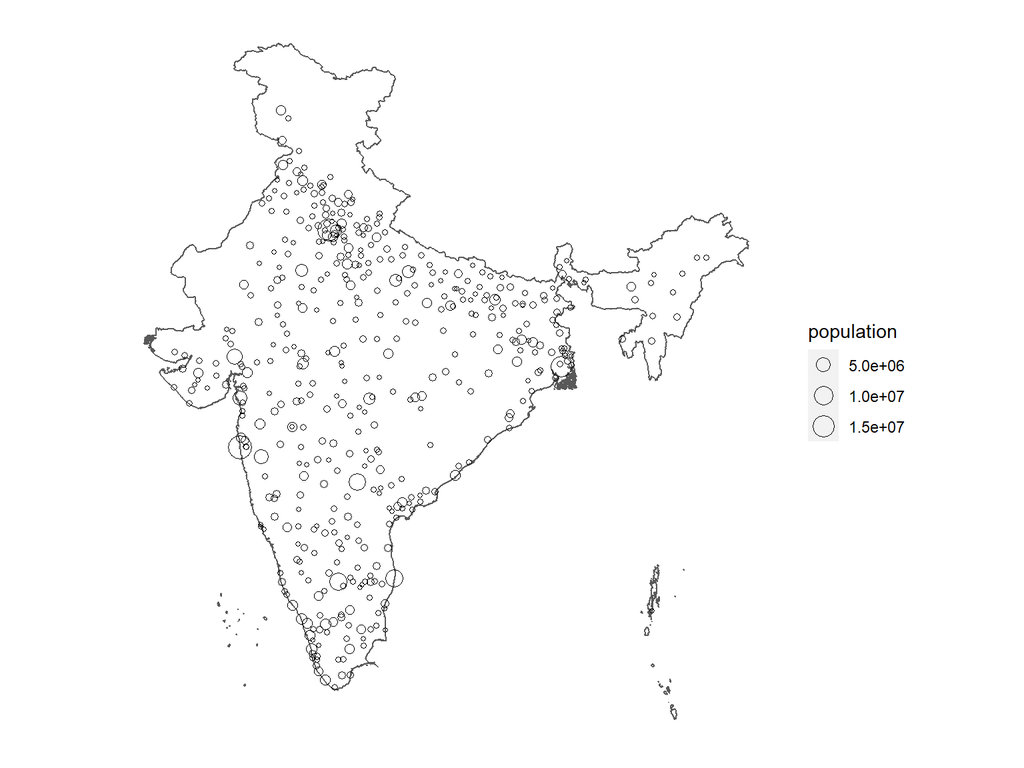

```r
plot <- ggplot() +
  theme(
    axis.text = element_blank(),
        axis.title = element_blank(),
        axis.ticks = element_blank(),
        panel.grid = element_blank(),
        panel.background = element_blank()
  ) +
  geom_sf(data = india, fill = NA) +
  geom_sf(data = geo_data_2011_sex_ratio, aes(size = population), shape = 21)
plot
```

Already looks much cleaner!

# Improvements

#### Changing population plot parameters and legend

Now we shall try and turn the formatting of the sizes into something more understandable

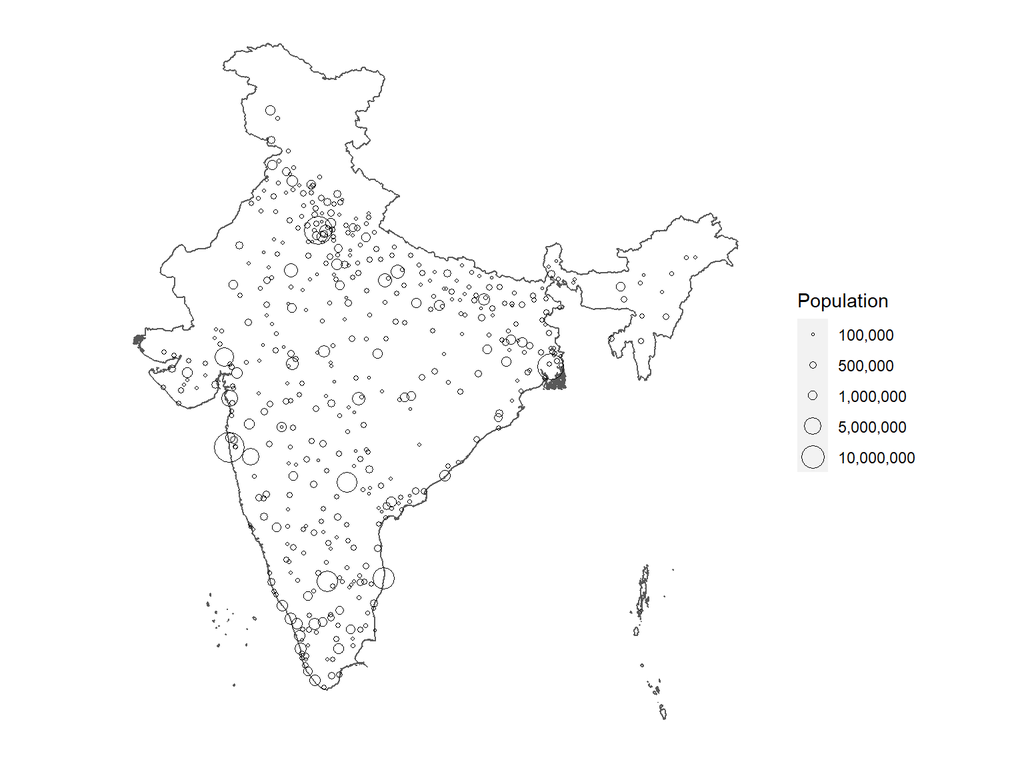

```r
plot <- ggplot() +
  theme(
    axis.text = element_blank(),
        axis.title = element_blank(),
        axis.ticks = element_blank(),
        panel.grid = element_blank(),
        panel.background = element_blank()
  ) +
  geom_sf(data = india, fill = NA) +
  geom_sf(data = geo_data_2011_sex_ratio, aes(size = population), shape = 21) +
    scale_size_continuous(name = "Population", range = c(0.5,8),
                          limits = c(100000,20000000),
                          breaks = c(100000,500000,1000000,5000000,10000000),
                          labels = c("100,000","500,000","1,000,000","5,000,000","10,000,000"))

plot
```

# Improvements

#### Changing sex ratio colors and legend

Now we shall add the sex ratios and color them in a red-green color scale.

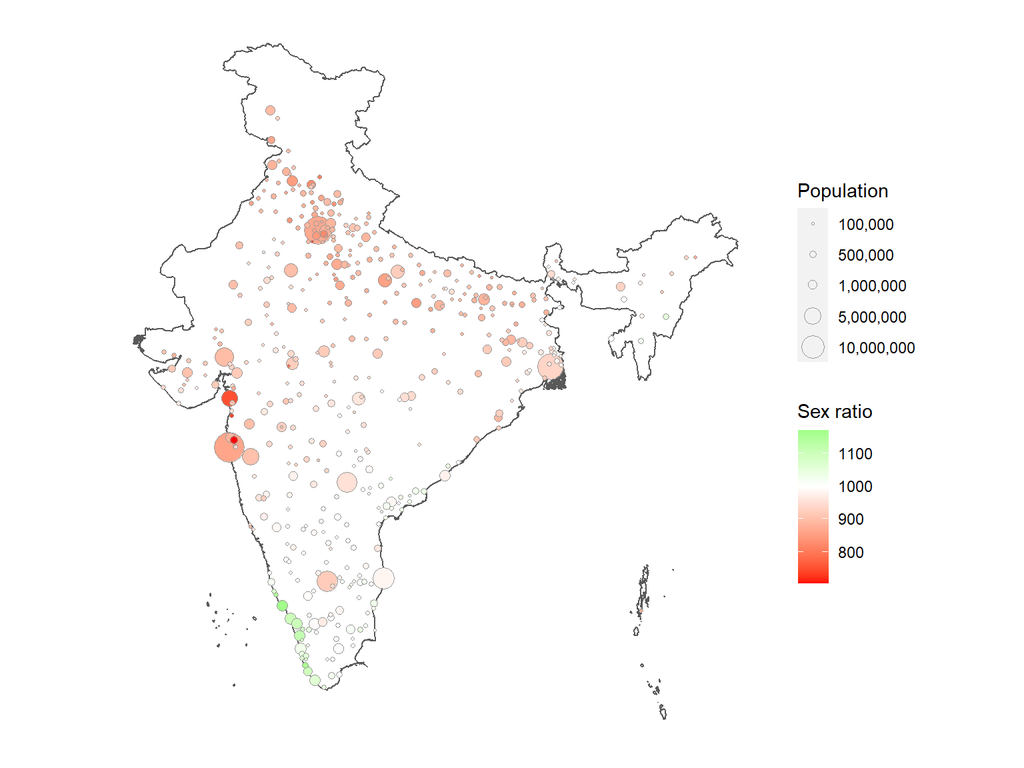

```r
plot <- ggplot() +
  theme(
    axis.text = element_blank(),
        axis.title = element_blank(),
        axis.ticks = element_blank(),
        panel.grid = element_blank(),
        panel.background = element_blank()
  ) +
  geom_sf(data = india, fill = NA) +
  geom_sf(data = geo_data_2011_sex_ratio, aes(size = population, fill = sex_ratio), shape = 21, color = "grey60") +
    scale_size_continuous(name = "Population", range = c(0.5,8),
                          limits = c(100000,20000000),
                          breaks = c(100000,500000,1000000,5000000,10000000),
                          labels = c("100,000","500,000","1,000,000","5,000,000","10,000,000")) +
    scale_fill_gradient2(name = "Sex ratio",
                      low = "red",
                      mid = "white",
                      high = "green",
                      midpoint = 1000)

plot
```

# Final

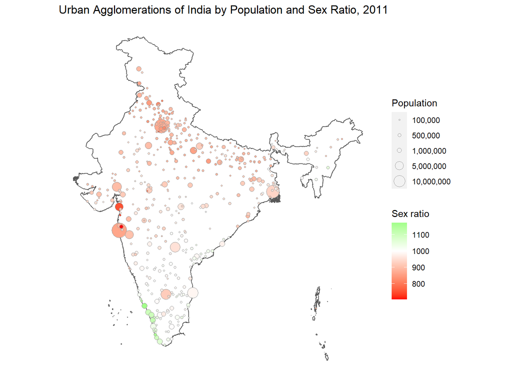